# LC-MS Metabolomics Data Processing

## Exercise 1:

#### Find the EIC peak for the citrulline metabolite?

**What is the retention time range of this metabolite?**

## Solution 1 :

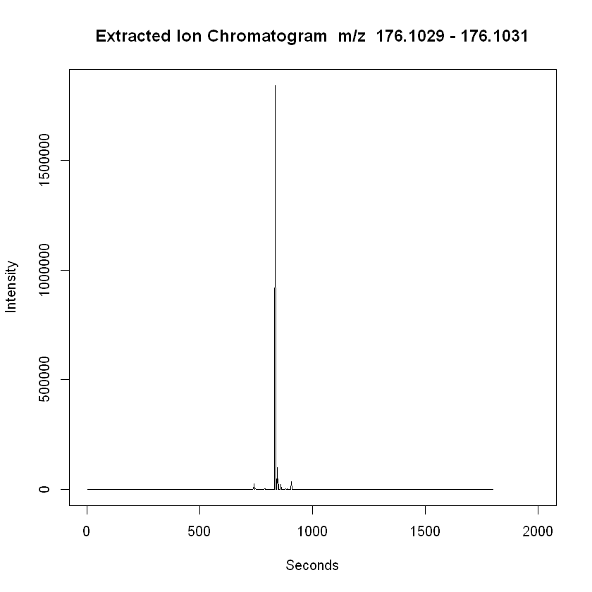

```r
# Exact mass for citrulline:  175.095691 g/mol
# Find the extracted ion chromatogram (EIC) for the adduct M+H (add the mass of H to the mass)

plotEIC(xraw,mzrange=c(176.1029,176.1031),#mzrange is the parameter range within which the mass detected by the MS is (mass after ionisation)
        rtrange=c(0,2000), col="black") #rtrange is the parameter range for the time range in which the metabolite is eluted on the LC column
```

## Exercice 2

This mass corresponds to the M+H adducts of a metabolite found in these samples: *132.076*

- The metabolite formula is the following: C4H9N3O2
- This metabolite has been found to be linked to metabolic reactions in the human metabolic network simulating kidney failure
- Furthermore this metabolite is identified as an amino-acids.

**Using the information above and the [HMDB database](https://hmdb.ca/spectra/ms/search) find which metabolite is it and plot its EIC**

## Solution 2

Using HMDB the possible metabolites are:

- Creatine
- 3-Guanidinopropionic acid

Creatine is associated with kidney failure

Hence it's creatine

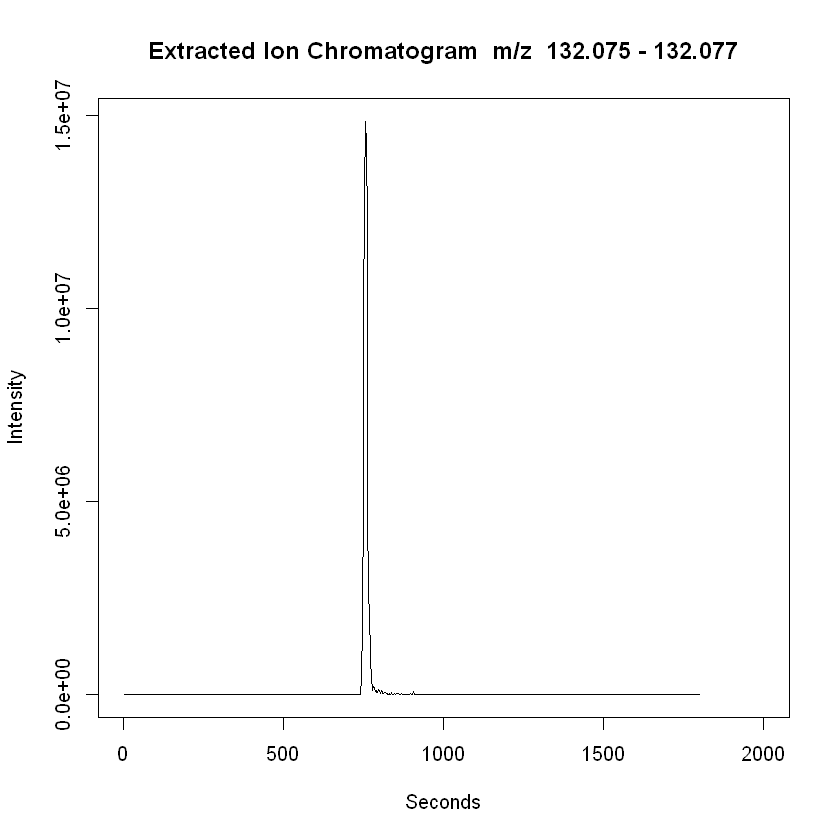

```r
plotEIC(xraw,mzrange=c(132.075,132.077),#mzrange is the parameter range within which the mass detected by the MS is (mass after ionisation)
        rtrange=c(0,2000), col="black") #rtrange is the parameter range for the time range in which the metabolite is eluted on the LC column
```